# Reference-guided Broad Cell-class Annotation Pilot — All 21 CellBin Samples

Author

Codex

Published

November 11, 2026

## Scope and decision

This report documents a gated reference-guided pilot. All 21 patients entered the pilot, but the analysis stopped before full-cohort expansion because the predeclared uncertainty gate failed. Pilot labels are diagnostic only and were not promoted to formal provisional annotations.

```python
from pathlib import Path
import platform
import sys

import pandas as pd
from IPython.display import Image, display

cwd = Path.cwd()
root = cwd.parent if cwd.name == "scripts" else cwd
out = root / "results/cell bin/CellBin_BroadClass_pilot_21samples"

mapping = pd.read_csv(out / "Reference18_to_BroadClass_mapping.tsv", sep="\t")
audit = pd.read_csv(out / "Reference18_input_audit.tsv", sep="\t")
gate = pd.read_csv(out / "BroadClass_pilot_gate_summary.tsv", sep="\t")
cv = pd.read_csv(out / "Pilot_reference_CV_summary.tsv", sep="\t")
sample = pd.read_csv(out / "Pilot_summary_by_sample.tsv", sep="\t")
```

The primary method was SingleR 2.12.0 using donor × unchanged-Reference18-state pseudobulk profiles. The query pilot contained 500 G10/U20 CellBins from each sample (10,500 total), selected deterministically across each sample’s nGenes range. See `BroadClass_method_selection.md` for the pre-execution rationale and gate definitions.

## Frozen Reference18 mapping

```python
mapping[
    [
        "state_order",
        "state18",
        "n_reference_cells",
        "broad_class",
        "biological_basis",
    ]
]
```

|  | state_order | state18 | n_reference_cells | broad_class | biological_basis |
| --- | --- | --- | --- | --- | --- |
| 0 | 1 | Alveolar/resident macrophage | 3958 | Immune | Myeloid immune lineage. |
| 1 | 2 | Inflammatory monocyte/macrophage | 4973 | Immune | Monocyte/macrophage immune lineage. |
| 2 | 3 | Dendritic cell | 1069 | Immune | Antigen-presenting immune lineage. |
| 3 | 4 | T | 7377 | Immune | Lymphoid immune lineage. |
| 4 | 5 | NK | 2623 | Immune | Lymphoid immune lineage. |
| 5 | 6 | Mast/Basophil | 1659 | Immune | Granulocytic immune lineage. |
| 6 | 7 | B | 5189 | Immune | Lymphoid immune lineage. |
| 7 | 8 | Ciliated epithelial | 2159 | Epithelial | Airway epithelial lineage. |
| 8 | 9 | AT2/alveolar transitional | 4234 | Epithelial | Alveolar epithelial lineage. |
| 9 | 10 | Secretory/other airway epithelial | 1950 | Epithelial | Airway epithelial lineage. |
| 10 | 11 | AT1 | 815 | Epithelial | Alveolar epithelial lineage. |
| 11 | 12 | Blood endothelial | 8063 | Endothelial / vascular | Blood-vessel endothelial lineage. |
| 12 | 13 | Perivascular/mesothelial stromal | 2467 | Stromal | Pericyte, smooth-muscle and mesothelial stroma... |
| 13 | 14 | Fibroblast | 5680 | Stromal | Mesenchymal stromal lineage. |
| 14 | 15 | Lymphatic endothelial | 1937 | Endothelial / vascular | Lymphatic endothelial lineage. |
| 15 | 16 | Plasma | 644 | Immune | Antibody-secreting immune lineage. |
| 16 | 17 | Basal-like epithelial | 842 | Epithelial | Basal epithelial lineage. |
| 17 | 18 | Myofibroblast | 1853 | Stromal | Contractile mesenchymal stromal lineage. |

All 18 original states remain unchanged. Only a traceable broad-class mapping was added.

## Input audit

```python
audit
```

|  | check | value | status |
| --- | --- | --- | --- |
| 0 | reference_cells | 57492 | PASS |
| 1 | reference_states | 18 | PASS |
| 2 | reference_genes | 18966 | PASS |
| 3 | reference_sparse_encoding | csc_matrix | PASS |
| 4 | reference_sparse_nnz | 114089017 | PASS |
| 5 | reference_sample_nonnegative | True | PASS |
| 6 | reference_sample_integer_like | True | PASS |
| 7 | reference_mapping_id_order | True | PASS |
| 8 | joint_shape | (799172, 32089) | PASS |
| 9 | joint_sparse_encoding | csr_matrix | PASS |
| 10 | joint_sample_nonnegative | True | PASS |
| 11 | joint_sample_integer_like | True | PASS |
| 12 | qc_joint_id_order | True | PASS |
| 13 | assigned_g10_u20_cellbins | 359329 | PASS |
| 14 | samples | 21 | PASS |
| 15 | reference_unique_gene_symbols | 18966 | PASS |
| 16 | joint_unique_gene_symbols | 32069 | PASS |
| 17 | common_unique_gene_symbols | 18966 | PASS |
| 18 | candidate_donor_metadata_columns | donor_id | REVIEW |
| 19 | reference_h5_top_keys | genes;reference;reference_cells;spatial | PASS |

The reference contained 57,492 cells, 18 states, 18,966 raw-count genes, and 124 donors. All 18,966 unique reference gene symbols were present in the Joint V1 gene union. Joint V1 and the QC Parquet had identical global CellBin ID order, and 359,329 assigned CellBins passed G10/U20.

## Pilot gate

```python
gate
```

|  | check | value | status | interpretation |
| --- | --- | --- | --- | --- |
| 0 | pilot_input_output_id_match | True | PASS | 10,500 IDs in identical order |
| 1 | reference_donor_grouped_cv_accuracy | 0.9988751406074241 | PASS | >0.65 gate |
| 2 | default_pruning_unknown_fraction | 0.0 | FAIL | zero Unknown means forced four-class labels |
| 3 | query_median_max_score | 0.05913498454010095 | REVIEW | method-specific, not probability |
| 4 | cv_correct_max_score_p05 | 0.36267706044499215 | REVIEW | held-out donor reference profiles |
| 5 | query_to_cv_score_domain_ratio | 0.1630513506080158 | FAIL | strong reference-query score-domain shift |
| 6 | predicted_class_marker_ge2_fraction | 0.32961904761904764 | REVIEW | orthogonal support; not sole gate |
| 7 | spearman_max_score_vs_nGenes | 0.5636118929435723 | REVIEW | moderate depth association |
| 8 | spearman_max_score_vs_nUMI | 0.5600102880255818 | REVIEW | moderate depth association |
| 9 | spearman_delta_vs_nGenes | 0.35137465201253276 | REVIEW | moderate/weak depth association |
| 10 | spearman_delta_vs_nUMI | 0.3478565273198151 | REVIEW | moderate/weak depth association |
| 11 | full_21_sample_expansion_authorized | False | STOP | pilot uncertainty gate failed |

Key results:

- donor-grouped Reference18 self-validation accuracy was 99.89%;
- default SingleR pruning returned zero Unknown query CellBins;
- the CellBin pilot maximum-score distribution was strongly separated from held-out reference profiles (median query score 0.059 versus reference correct-profile P5 0.363; scores are not probabilities);
- only 32.96% of forced query labels had at least two independent canonical markers for their predicted broad class;
- maximum score was moderately associated with nGenes/nUMI (Spearman about 0.56), but depth was not the sole failure mechanism.

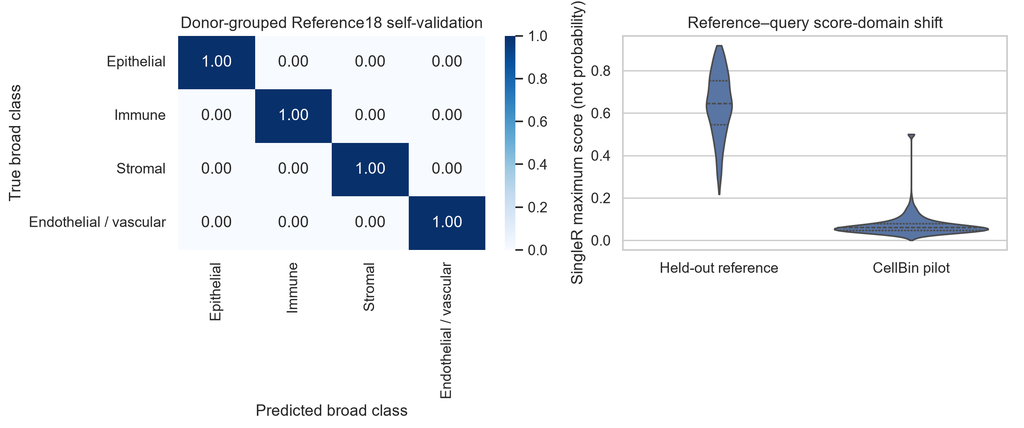

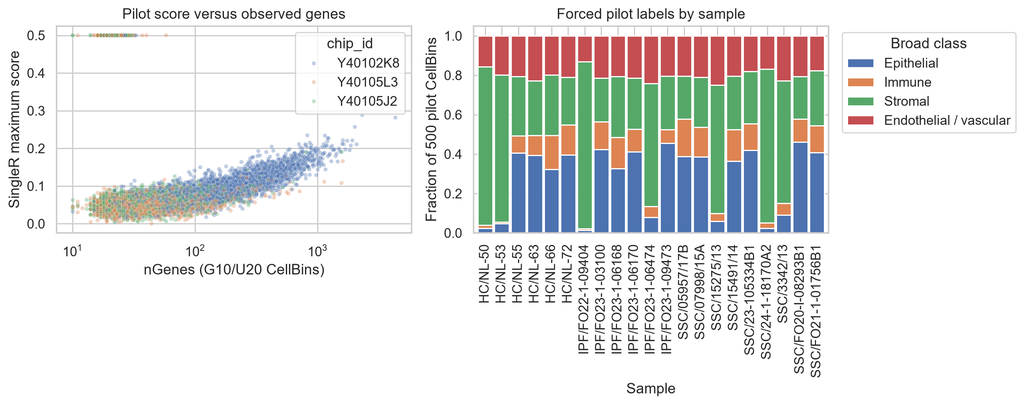

```python
for filename in [
    "Pilot_reference_CV_and_score_domain_shift.png",
    "Pilot_depth_and_sample_composition.png",
]:
    display(Image(filename=str(out / "pilot_figures" / filename)))
```

## Per-sample pilot diagnostics

```python
sample
```

|  | chip_id | sample_id | disease_group | n_pilot_cellbins | default_unknown_fraction | median_n_genes | median_n_umi | median_max_score | median_delta_next | predicted_marker_ge2_fraction | largest_predicted_class_fraction |
| --- | --- | --- | --- | --- | --- | --- | --- | --- | --- | --- | --- |
| 0 | Y40102K8 | HC/NL-50 | HC | 500 | 0.0 | 226.5 | 263.5 | 0.105911 | 0.057907 | 0.782 | 0.804 |
| 1 | Y40102K8 | HC/NL-53 | HC | 500 | 0.0 | 161.5 | 185.0 | 0.089678 | 0.044601 | 0.672 | 0.746 |
| 2 | Y40102K8 | IPF/FO22-1-09404 | IPF | 500 | 0.0 | 396.0 | 475.5 | 0.120208 | 0.060455 | 0.876 | 0.846 |
| 3 | Y40102K8 | IPF/FO23-1-06474 | IPF | 500 | 0.0 | 59.5 | 65.0 | 0.067067 | 0.021904 | 0.448 | 0.624 |
| 4 | Y40102K8 | SSC/15275/13 | SSc-ILD | 500 | 0.0 | 88.5 | 98.5 | 0.072363 | 0.029000 | 0.486 | 0.650 |
| 5 | Y40102K8 | SSC/24-1-18170A2 | SSc-ILD | 500 | 0.0 | 155.5 | 175.0 | 0.091650 | 0.052180 | 0.670 | 0.780 |
| 6 | Y40102K8 | SSC/3342/13 | SSc-ILD | 500 | 0.0 | 59.5 | 65.0 | 0.064726 | 0.020211 | 0.388 | 0.622 |
| 7 | Y40105J2 | HC/NL-55 | HC | 500 | 0.0 | 36.5 | 42.0 | 0.055961 | 0.014074 | 0.204 | 0.406 |
| 8 | Y40105J2 | HC/NL-63 | HC | 500 | 0.0 | 32.0 | 37.5 | 0.054469 | 0.014325 | 0.178 | 0.394 |
| 9 | Y40105J2 | IPF/FO23-1-03100 | IPF | 500 | 0.0 | 26.0 | 29.0 | 0.051634 | 0.013462 | 0.142 | 0.424 |
| 10 | Y40105J2 | IPF/FO23-1-09473 | IPF | 500 | 0.0 | 60.0 | 71.0 | 0.062840 | 0.017926 | 0.400 | 0.456 |
| 11 | Y40105J2 | SSC/23-105334B1 | SSc-ILD | 500 | 0.0 | 27.0 | 31.0 | 0.052993 | 0.013018 | 0.174 | 0.420 |
| 12 | Y40105J2 | SSC/FO20-I-08293B1 | SSc-ILD | 500 | 0.0 | 30.0 | 34.0 | 0.054043 | 0.013887 | 0.160 | 0.462 |
| 13 | Y40105J2 | SSC/FO21-1-01756B1 | SSc-ILD | 500 | 0.0 | 30.0 | 34.0 | 0.054121 | 0.013496 | 0.212 | 0.408 |
| 14 | Y40105L3 | HC/NL-66 | HC | 500 | 0.0 | 25.0 | 30.0 | 0.048092 | 0.012653 | 0.076 | 0.322 |
| 15 | Y40105L3 | HC/NL-72 | HC | 500 | 0.0 | 41.0 | 47.5 | 0.052247 | 0.014749 | 0.204 | 0.396 |
| 16 | Y40105L3 | IPF/FO23-1-06168 | IPF | 500 | 0.0 | 36.5 | 42.5 | 0.051969 | 0.014574 | 0.182 | 0.326 |
| 17 | Y40105L3 | IPF/FO23-1-06170 | IPF | 500 | 0.0 | 33.0 | 38.0 | 0.051613 | 0.012753 | 0.160 | 0.412 |
| 18 | Y40105L3 | SSC/05957/17B | SSc-ILD | 500 | 0.0 | 27.0 | 31.0 | 0.050097 | 0.013362 | 0.126 | 0.388 |
| 19 | Y40105L3 | SSC/07998/15A | SSc-ILD | 500 | 0.0 | 35.0 | 40.0 | 0.051706 | 0.013398 | 0.170 | 0.386 |
| 20 | Y40105L3 | SSC/15491/14 | SSc-ILD | 500 | 0.0 | 36.0 | 42.0 | 0.052237 | 0.013711 | 0.212 | 0.364 |

These summaries describe balanced pilot subsets, not full-sample cell-class proportions. No spatial plausibility maps were promoted because the uncertainty gate failed before full-cohort prediction.

## Interpretation

The four broad Reference18 classes are internally separable, but the selected SingleR configuration does not provide a defensible abstention behavior for the sparse FFPE CellBins. Applying an arbitrary score cutoff or filling labels from spatial position would violate the analysis constraints. Therefore the pilot does not establish that all 21 samples currently support interpretable, spatially plausible, cross-sample-stable broad-class annotation.

A possible next method-development step is target-depth synthetic reference downsampling with donor-held-out, class- and depth-stratified abstention calibration. That recovery analysis was not run automatically.

## Output status

Formal full-cohort files (`CellBin_BroadClass_predictions.parquet`, full sample uncertainty/marker/feasibility tables, 21 spatial prediction maps and three-chip comparison plots) were intentionally not created. Joint V1 was not modified.

## Environment

```python
print(f"Python: {sys.version}")
print(f"Platform: {platform.platform()}")
print(f"Results directory: {out}")
print((out / "work/pilot_R_sessionInfo.txt").read_text(encoding="utf-8"))
```

[output not shown]

## Render command

Render only after the separate analysis-approval gate required by `AGENTS.md`. The command must be launched inside a detachable tmux session.

```bash
#| eval: false
TS=$(date +"%y%m%d%H%M%S")
PROJ="/mnt/d/Lung ST/codex agent/stereo_seq/stereo_seq"
tmux new -d -s cellbin_broadclass_report \
  "powershell.exe -NoProfile -Command \"\$env:QUARTO_PYTHON='D:\\Lung ST\\codex agent\\stereo_seq\\stereo_seq\\envs\\stereo_seq_py\\Scripts\\python.exe'; quarto render 'D:\\Lung ST\\codex agent\\stereo_seq\\stereo_seq\\scripts\\cellbin_broadclass_pilot_21samples.qmd' --output-dir 'D:\\Lung ST\\codex agent\\stereo_seq\\stereo_seq\\results' --execute-daemon 0 --no-clean --quiet *> 'D:\\Lung ST\\codex agent\\stereo_seq\\stereo_seq\\logs\\cellbin_broadclass_pilot_report_${TS}.log'; Move-Item -LiteralPath 'D:\\Lung ST\\codex agent\\stereo_seq\\stereo_seq\\results\\cellbin_broadclass_pilot_21samples.html' -Destination 'D:\\Lung ST\\codex agent\\stereo_seq\\stereo_seq\\results\\cellbin_broadclass_pilot_21samples_${TS}.html'\""
```